# Inferencia paramétrica

#### Ejemplo Bsplines: Bootstrap no paramétrico, bootstrap paramétrico y máxima verosimilitud

Ilustraremos los métodos usando un ejemplo de suavizamiento tomado del libro [The Elements of Statistical Learning (Hastie, Tibshirani, Friedman)](https://web.stanford.edu/~hastie/Papers/ESLII.pdf) para esto comenzamos creamos una base de datos artificial:

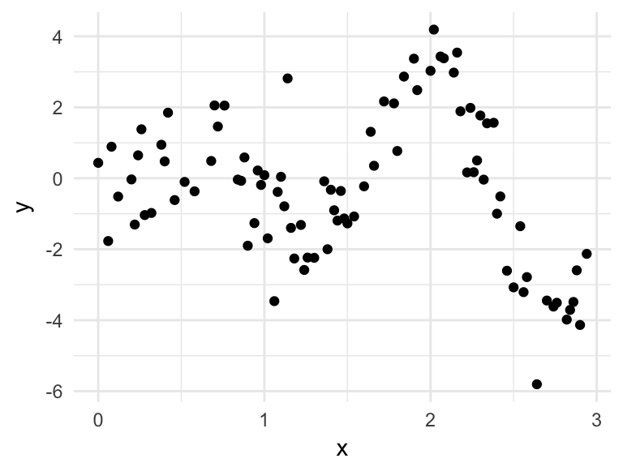

```r
set.seed(90984)
# simple harmonic motion
shm <- function(t, A = 1.5, omega = 4){ # Esta es una función sinusoidal
    t * A * sin(omega * t)
}
n <- 90
x <- sample(seq(0, 3, 0.02), n) # creamos una base con n observaciones
y <- shm(x) + rnorm(length(x), sd = 1)
outliers <- sample(1:length(y), 4)  # elijo 4 puntos al azar a los que agrego ruido
y[outliers] <- y[outliers] + rnorm(4, sd = 2)
toy <- data.frame(x, y)

ggplot(toy, aes(x, y)) +
  geom_point()
```

En nuestro ejemplo los datos consisten en pares $z_i=(x_i, y_i)$ donde $y_i$ se entiende como la *respuesta* o la *salida* correspondiente a $x_i$. De la gráfica de los datos es claro que la relación entre $x$ y $y$ no es lineal, por lo que usaremos un método de expansiones de base que permite mayor flexibilidad.

La idea básica atrás de **expansión de bases** es aumentar la dimensión del espacio de covariables (o predictores) creando variables adicionales que consisten en transformaciones de las variables originales $X$, para luego usar modelos lineales en el espacio aumentado. Si denotamos por $h_m(X)$ la m-ésima transformación de $X$, con $m = 1,...,M$, podemos modelar:

$$f(X)=\sum_{i=1}^M \beta_m h_m(X)$$

Lo conveniente de este enfoque es que una vez que determinamos las funciones base $h_m$ los modelos son lineales en estas nuevas variables y podemos explotar las ventajas de usar modelos lineales. En lo que sigue supondremos que $X$ es unidimensional (como en el ejemplo).

Dentro de los métodos de expansión de bases estudiaremos los splines. Una función spline está fromada por polinomios de grado k, cada uno definido sobre un intervalo, y se unen entre sí en los límites de cada intervalo. Los lugares donde se unen se conocen como nudos (knots). Antes de proceder entendamos los polinomios por pedazos: un polinomio por pedazos se obtiene dividiendo el dominio de X en intervalos contiguos y representando a $f$ por medio de un polinomio en cada intervalo. Por ejemplo una constante por pedazos:

```r
library(Hmisc)
```

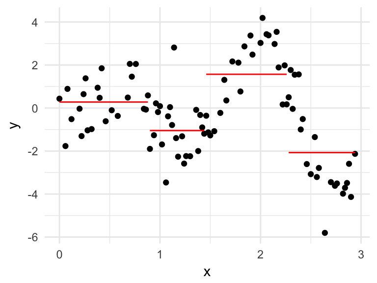

```r
toy_k <- toy
toy_k <- toy %>%
    mutate(int = cut2(x, g = 4)) %>%
    group_by(int) %>%
    mutate(media = mean(y))

ggplot(toy_k, aes(x, y)) +
  geom_point() +
  geom_line(aes(x, y = media, group = int), color = "red")
```

Debido a que dividimos el dominio en regiones disjuntas, el estimador de mínimos cuadrados para el modelo $f(X)=\sum \beta_m h_m(X)$ es $\hat{\beta_m} = \bar{Y}_m$ la media de $Y$ en cada región con $m=1,2,3,4$.

Ahora ajustamos un polinomio lineal por pedazos:

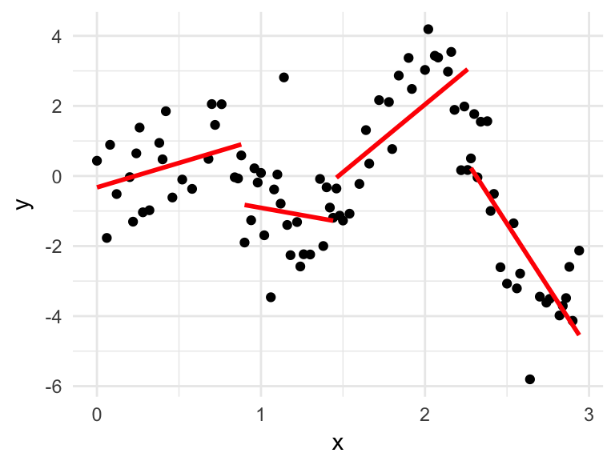

```r
ggplot(toy_k, aes(x, y)) +
  geom_point() +
  geom_smooth(method = "lm", aes(x, y = y, group = int), color = "red", se = FALSE)
```

Normalmente preferimos que la función sea continua en los nudos, esto conlleva a restricciones es los parámetros o al uso de bases que incorporen las restricciones. Más aún, es conveniente restringir no solo a continuidad de la función sino a continuidad de las derivadas.

Supongamos que decidimos ajustar splines cúbicos a los datos, con 3 nudos ubicados en los cuartiles de $X$. Esto corresponde a un espacio lineal de funciones, la dimensión del espacio es 7 (4 regiones $\times$ 4 parámetros por región - 3 nodos por 3 restricciones por nodo).

```r
library(fda) # paquete con funciones útiles de splines
```

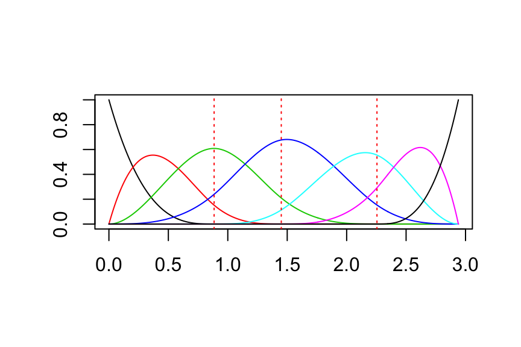

```r
knots <- quantile(x)
# usamos la función create.bspline.basis para crear la base
base <- create.bspline.basis(
    norder = 4, # polinomios cúbicos
    breaks = knots # nodos en los cuartiles de x
    )
plot(base, lty = "solid")
```

Podemos representar el espacio por medio de una expansión lineal en las funciones base:

$$\mu(x) = \sum_{j=1}^7 \beta_j h_j(x)$$

donde $h_j(x)$ son las 7 funciones que graficamos en la figura superior. Podemos pensar en $\mu(x)$ como una representación de la media condicional $E(Y|X=x)$.

```r
H <- eval.basis(x, base)
head(H)
```

```
#>      bspl4.1  bspl4.2  bspl4.3 bspl4.4 bspl4.5 bspl4.6 bspl4.7
#> [1,]  0.0409 4.49e-01 4.42e-01  0.0674  0.0000   0.000 0.00000
#> [2,]  0.0000 0.00e+00 1.36e-06  0.1635  0.5606   0.276 0.00000
#> [3,]  0.0000 0.00e+00 0.00e+00  0.0751  0.4533   0.462 0.00948
#> [4,]  0.0000 2.27e-05 2.34e-01  0.6697  0.0963   0.000 0.00000
#> [5,]  0.0000 1.02e-02 4.17e-01  0.5490  0.0236   0.000 0.00000
#> [6,]  0.0000 0.00e+00 0.00e+00  0.0837  0.4714   0.439 0.00608
```

Sea H la matriz de $n \times 7$, donde el elemento $ij$ corresponde a $h_j(x_i)$. Entonces, el estimador usual de $\beta$ (obtenido minimizando el error cuadrático) esta dado por:
$$\hat{\beta} = (H^TH)^{-1}H^Ty$$

y con esto obtenemos: $\hat{\mu}(x) = \sum_{j=1}^7 \hat{\beta_j} h_j(x)$

```r
beta_hat <- as.vector(solve(t(H) %*% H) %*% t(H) %*% toy$y)
beta_hat
```

```
#> [1] -0.571  0.526  0.937 -3.140  9.007 -8.912 -1.665
```

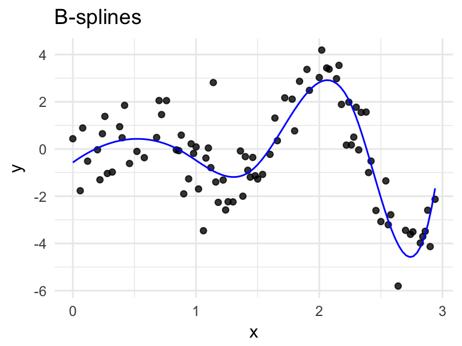

```r
# creamos una función que calcula mu(x)
mu <- function(x, betas){
    as.numeric(betas %*% t(eval.basis(x, base)))
}

ggplot(toy, aes(x = x, y = y)) +
    geom_point(alpha = 0.8) +
    stat_function(fun = mu, args = list(betas = beta_hat), color = "blue") +
    labs(title = "B-splines")
```

**Bootstrap no paramétrico**. Usemos bootstrap para calcular errores estándar, para esto tomamos muestras con reemplazo de los pares $z_i = (x_i,y_i)$, para cada muestra *bootstrap* $Z^*$ ajustamos un polinomio cúbico $\hat{\mu}^*(x)$ y construimos bandas de confianza usando los intervalos de cada punto.

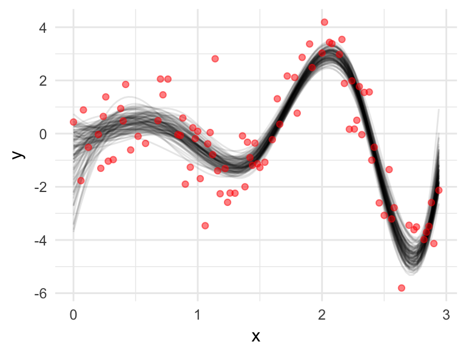

```r
splinesBoot <- function(){
    toy_boot <- sample_n(toy, size = n, replace = TRUE)
    H <- eval.basis(toy_boot$x, base)
    as.vector(solve(t(H) %*% H) %*% t(H) %*% toy_boot$y)
}
betas <- rerun(4000, splinesBoot()) %>% reduce(rbind)

splines_boot <- ggplot(toy, aes(x = x, y = y))

for(i in 1:100){
  splines_boot <- splines_boot +
    stat_function(fun = mu, args = list(betas = betas[i, ]), alpha = 0.1)
}

splines_boot + geom_point(color = "red", alpha = 0.5)
```

La gráfica superior muestra 100 replicaciones bootstrap del suavizamiento. Construyamos los intervalos bootstrap, en cada $x$ encontramos el 2.5% más chico y más grande.

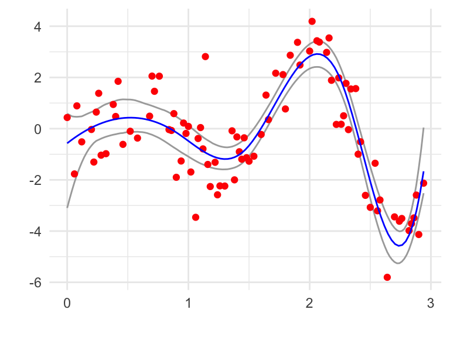

```r
# construimos los intervalos
x_grid <- seq(knots[1], knots[5], 0.02) # creamos un grid para evaluar mu(x)
H <- eval.basis(x_grid, base) # Evalúo la base en el rango
betas_list <- split(betas, seq(nrow(betas)))
y <- purrr::map_df(betas_list, ~ data_frame(x = x_grid, mu = as.vector(. %*% t(H))))
limites <- y %>%
    group_by(x) %>%
    summarise(
        limite_inf = quantile(mu, probs = 0.025),
        limite_sup = quantile(mu, probs = 0.975)
    )

ggplot(limites) +
    geom_line(aes(x = x, y = limite_inf), color = "darkgray") +
    geom_line(aes(x = x, y = limite_sup), color = "darkgray") +
    geom_point(data = toy, aes(x = x, y = y), color = "red") +
    stat_function(fun = mu, args = list(betas = beta_hat), color = "blue") +
    labs(x = "", y = "")
```

Supongamos ahora que los errores se distribuyen normal:
$$y = \mu(x) + \epsilon; \epsilon \sim N(0, \sigma^2)$$
$$\mu(x) = \sum_{j=1}^7 \beta_j h_j(x)$$

utilicemos **bootstrap paramétrico**, simularemos
$$y_i^* = \hat{\mu}(x_i) + \epsilon_i^*; \epsilon_i^* \sim N(0,\hat{\sigma}^2)$$

Para implementar bootstrap paramétrico comencemos calculando los estimadores de máxima verosimilitud:
$$\hat{\beta} = (H^TH)^{-1}H^Ty$$
y
$$\hat{\sigma}^2=1/n \sum_{i=1}^n(y_i-\hat{\mu}(x_i))^2$$

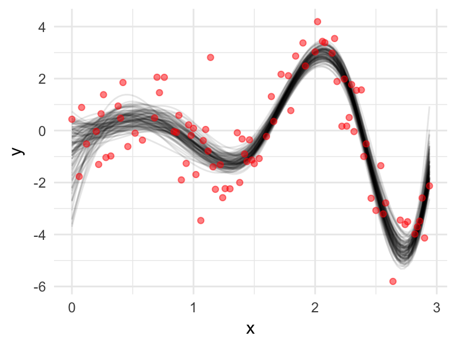

```r
mu_hat <- mu(toy$x, beta_hat)
sigma_hat <- sqrt(1 / n * sum((toy$y - mu_hat) ^ 2))

# creamos las muestras bootstrap (paramétrico)
splinesBootP <- function(){
    toy_boot <- data.frame(x = toy$x, y = mu_hat + rnorm(n, 0, sigma_hat))
    H <- eval.basis(toy_boot$x, base)
    as.vector(solve(t(H) %*% H) %*% t(H) %*% toy_boot$y)
}

betas_p <- rerun(4000, splinesBootP()) %>% reduce(rbind)

splines_boot_p <- ggplot(toy, aes(x = x, y = y))
for(i in 1:100){
    splines_boot_p <- splines_boot_p +
        stat_function(fun = mu, args = list(betas = betas_p[i, ]), alpha = 0.1)
}

splines_boot + geom_point(color = "red", alpha = 0.5)
```

y construímos intervalos

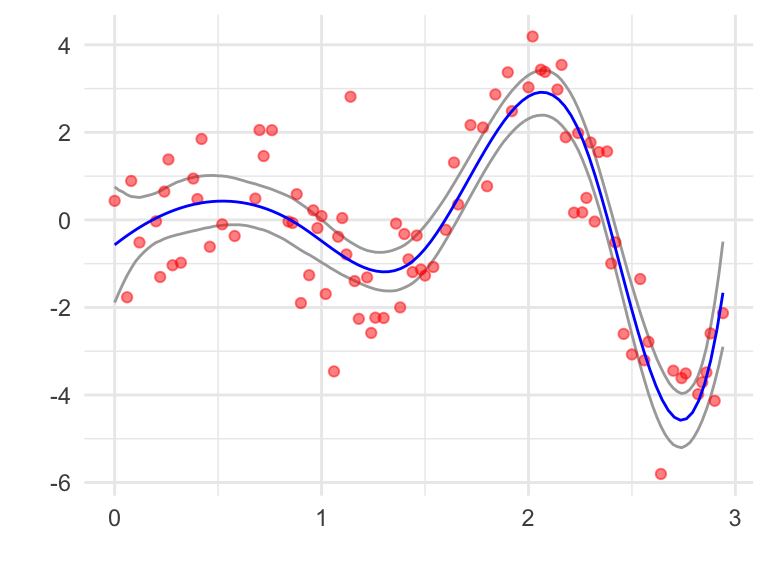

```r
# construimos los intervalos
x_grid <- seq(knots[1], knots[5], 0.02) # creamos un grid para evaluar mu(x)
H <- eval.basis(x_grid, base) # Evalúo la base en el rango
y <- betas_p %*% t(H) # calculo mu(x*)

betas_list <- split(betas_p, seq(nrow(betas)))
y <- purrr::map_df(betas_list, ~ data_frame(x = x_grid, mu = as.vector(. %*% t(H))))
limites <- y %>%
  group_by(x) %>%
  summarise(
    limite_inf = quantile(mu, probs = 0.025),
    limite_sup = quantile(mu, probs = 0.975)
    )

ggplot(limites) +
    geom_line(aes(x = x, y = limite_inf), color = "darkgray") +
    geom_line(aes(x = x, y = limite_sup), color = "darkgray") +
    geom_point(data = toy, aes(x = x, y = y), color = "red", alpha = 0.5) +
    stat_function(fun = mu, args = list(betas = beta_hat), color = "blue") +
    labs(x = "", y = "")
```

Máxima verosimilitud:
$$\hat{Var}(\hat{\beta})=(H^T H) ^{-1}\hat{\sigma}^2$$
donde
$$\hat{\sigma}^2=1/n \sum_{i=1}^n(y_i-\hat{\mu}(x_i))^2$$
,

ahora, la matriz de información de $\theta=(\beta,\sigma^2)$ es una diagonal con bloques y el bloque correspondiente a $\beta$ es:
$$I(\beta)=(H^TH)/\sigma^2$$
de tal manera que la varianza estimada es $I(\beta)=(H^TH)/\hat{\sigma}^2$. Podemos usar esto para construir las bandas en de errores estándar $\hat{\mu}(x) = h(x)^T\hat{\beta}$ es:

$$\hat{se}=[h(x)^T(H^TH)^{-1}h(x)]^{1/2}\hat{\sigma}$$

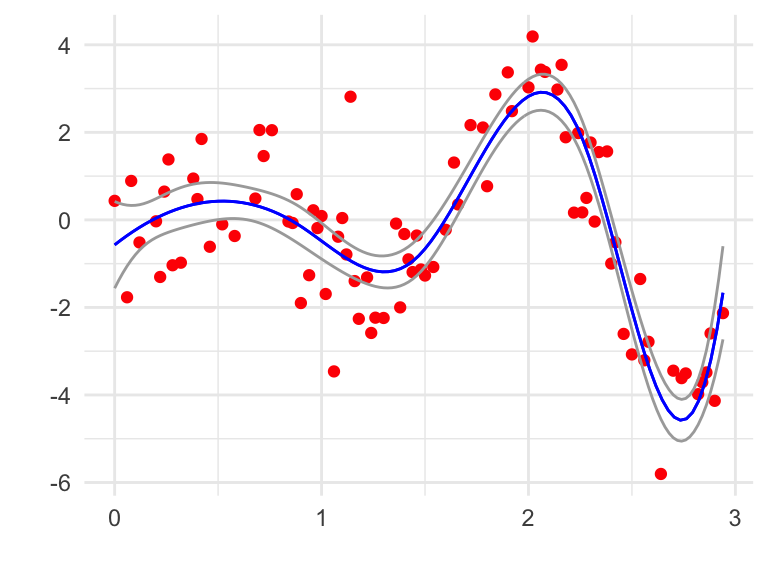

```r
seMu <- function(x){
  # calculo h(x)
  h <- eval.basis(x, base)
  # calcilo se_hat(x)
  se_hat <- as.numeric((h %*% solve(t(H) %*% H) %*% t(h)) ^ (1 / 2) * sigma_hat)
  se_hat
}
max_ver_errores <- data.frame(x = x_grid,
  y_min = mu(x_grid, beta_hat) - 2 * sapply(x_grid, seMu),
  y_max = mu(x_grid, beta_hat) + 2 * sapply(x_grid, seMu)) %>%
  gather(cuantil, valor, y_min, y_max)

ggplot(toy) +
  geom_point(color = "red", aes(x = x, y = y)) +
  stat_function(fun = mu, args = list(betas = beta_hat), color = "blue") +
  geom_line(data = max_ver_errores, aes(x = x, y = valor, group = cuantil),
    color = "darkgray") +
    stat_function(fun = mu, args = list(betas = beta_hat), color = "blue") +
    labs(x = "", y = "")
```

En general el bootstrap paramétrico coinicide con máxima verosimilitud, la ventaja de *bootstrap* sobre máxima verosimilitud es que permite calcular estimaciones de máxima verosimilitud de errores estándar en escenarios donde no hay fórmulas disponibles.

Sean $X_1,...,X_n \sim N(\mu, 1)$. Sea $\theta = e^{\mu}$, crea una base de datos usando $\mu=5$ que consista de $n=100$ observaciones.

- Usa el método delta para estimar $\hat{se}$ y crea un intervalo del 95% de confianza. Usa boostrap paramétrico para crear un intervalo del 95%. Usa bootstrap no paramétrico para crear un intervalo del 95%. Compara tus respuestas.
- Realiza un histograma de replicaciones bootstrap para cada método, estas son estimaciones de la distribución de $\hat{\theta}$. El método delta también nos da una aproximación a esta distribución: $Normal(\hat{\theta},\hat{se}^2)$. Comparalos con la verdadera distribución de $\hat{\theta}$ (que puedes obtener vía simulación). ¿Cuál es la aproximación más cercana a la verdadera distribución?

Pista: $se(\hat{\mu}) = 1/\sqrt{n}$